# Razões em obras de arte

Allan Inocêncio de Souza Costa

22 de novembro de 2015

## Introdução

Neste trabalho investigamos a razão entre as dimensões de telas de diversos artistas.

Conforme observado pelo professor [José Antônio Salvador](http://www.dm.ufscar.br/profs/salvador/), as médias dessas razões para diferentes artistas, em geral, não parecem se aproximar da reverenciada [razão áurea](http://www.wikiwand.com/en/Golden_ratio), sendo talvez melhor estimadas pelo [número plástico](https://www.wikiwand.com/en/Plastic_number).

Utilizamos nesse estudo empírico uma [base de dados online](http://www.wga.hu/frames-e.html?/database/download/) consistindo de um arquivo no formato `xls` que pode ser aberto em qualquer software que trabalhe com planilhas, como LibreOffice Calc ou Excel. Optamos por utilizar o software [R](https://www.r-project.org/) para a análise dos dados.

O código fonte com os scripts utilizados para o processsamento dos dados e a criação dessa página está disponível [nesse repositório](https://github.com/allanino/razoes-obras-de-arte).

## Resultados

Apresentamos os resultados na forma de histogramas anotados com a razão média, o número plástico e a razão áurea.

Observamos médias relativamente próximas do número plástico para artistas como Rembrandt, van Gogh, Monet e Degas. Adicionamos alguns comentários específicos para cada histograma quando achamos pertinente.

Primeiro mostramos um histragrama com todas as obras de todos os artistas, após o que apresentamos histogramas de alguns artistas selecionado entre aqueles com maior quantidade de obras na base de dados.

### Todos os artistas

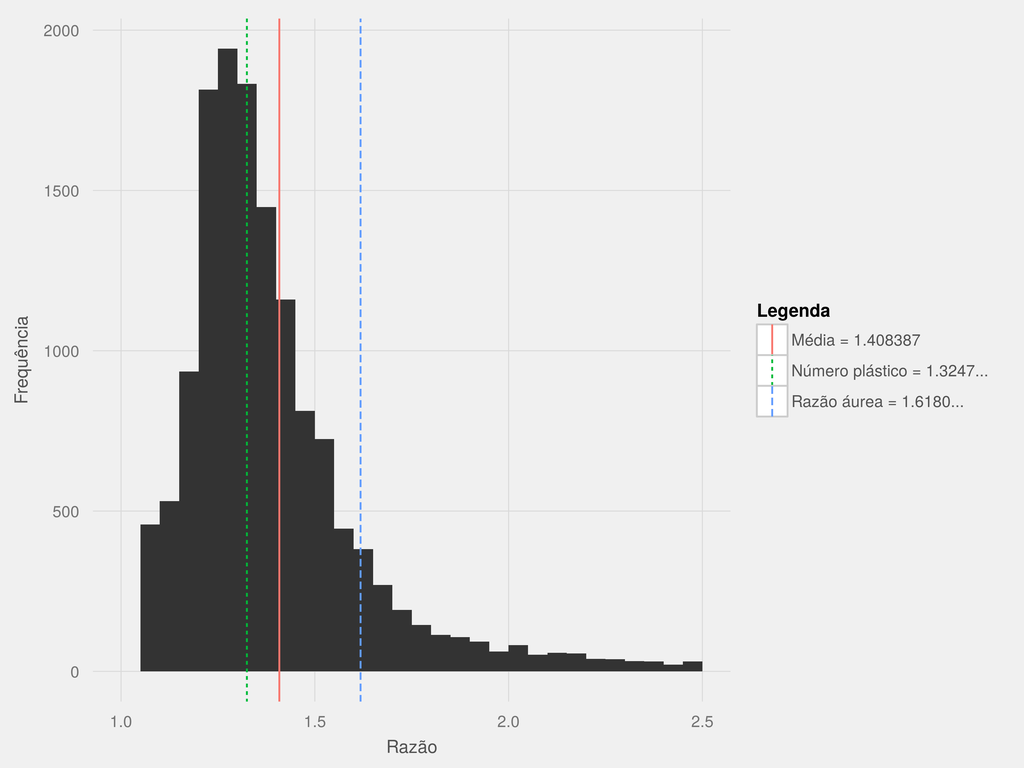

Observe como obtemos uma grande concentração de valores ao redor do pico em 1,25. Em contrapartida, não temos um pico próximo à razão áurea.

### Harmenszoon van Rijn Rembrandt

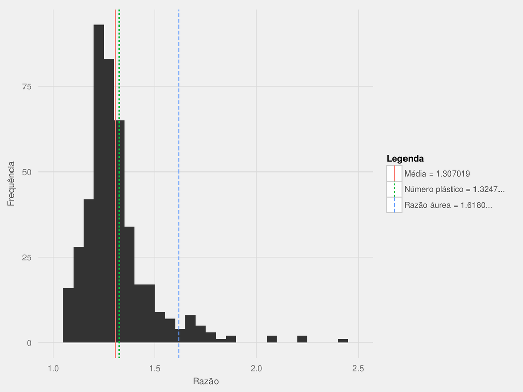

### Vincent van Gogh

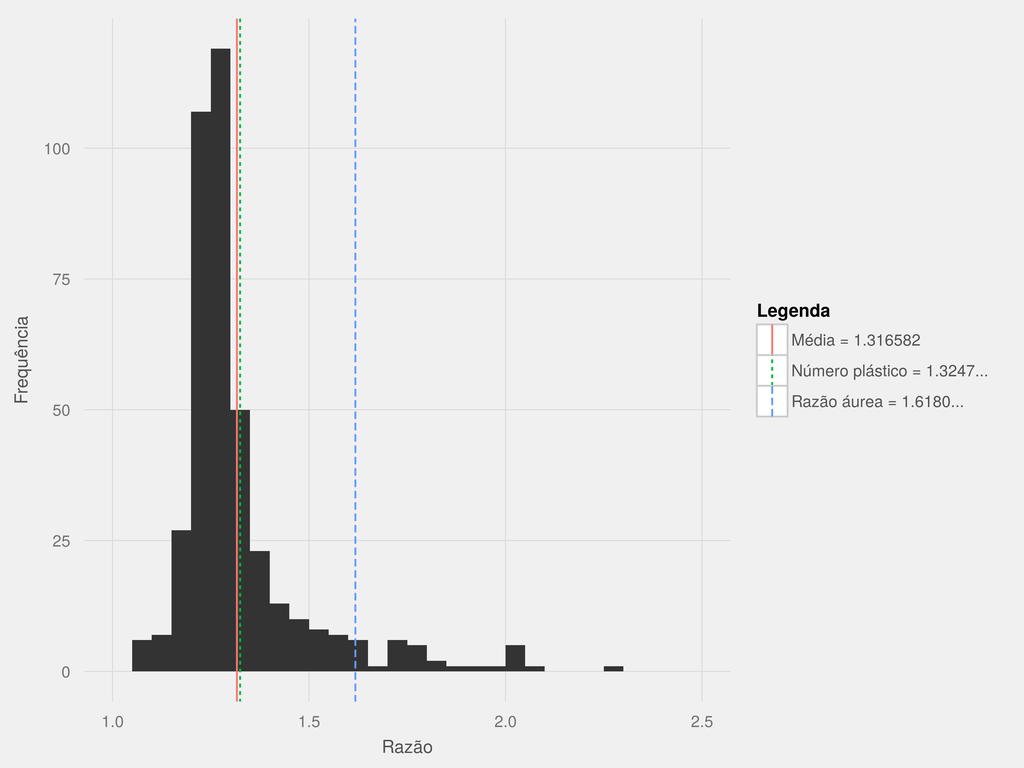

### Albrecht Dürer

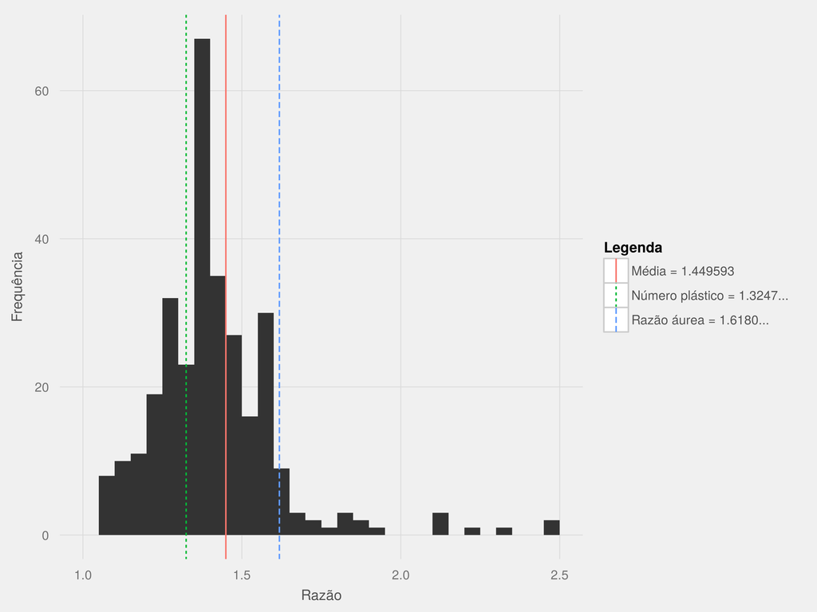

### El Greco

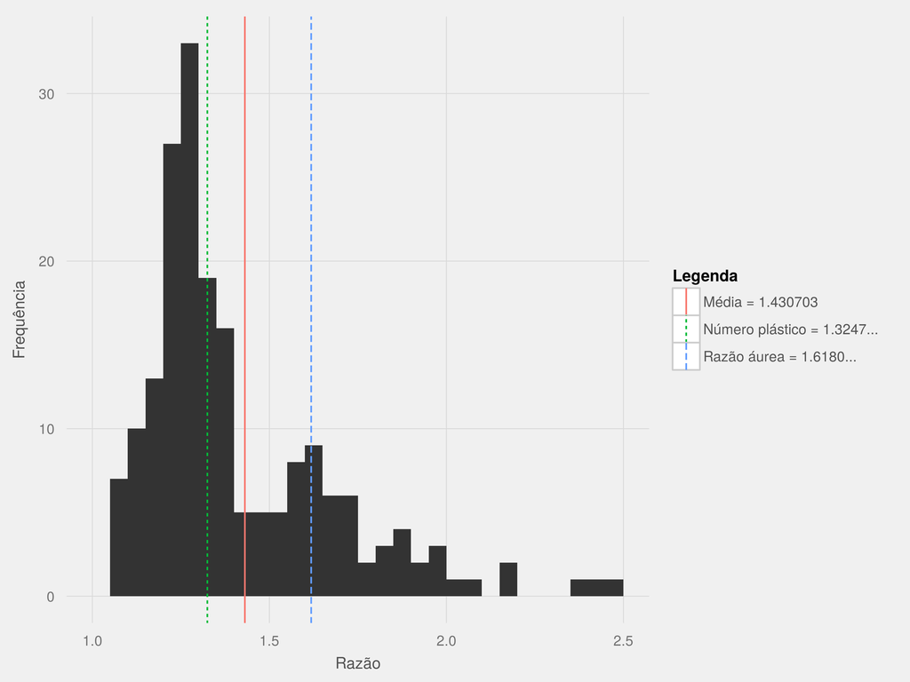

### Claude Monet

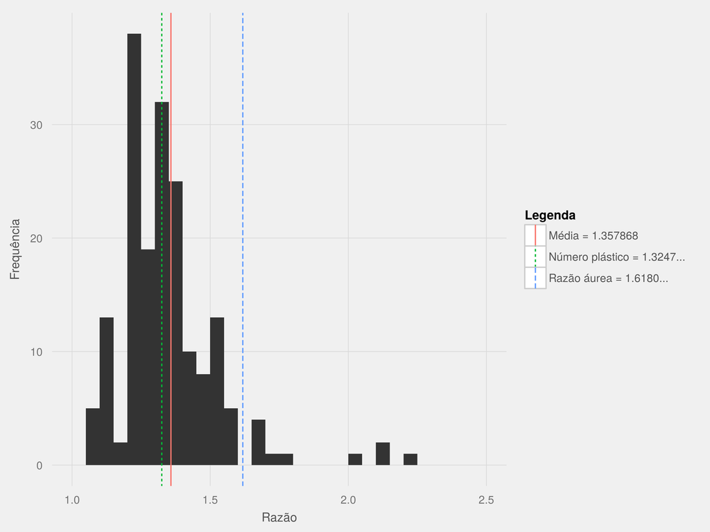

### Lucas the Elcer Cranach

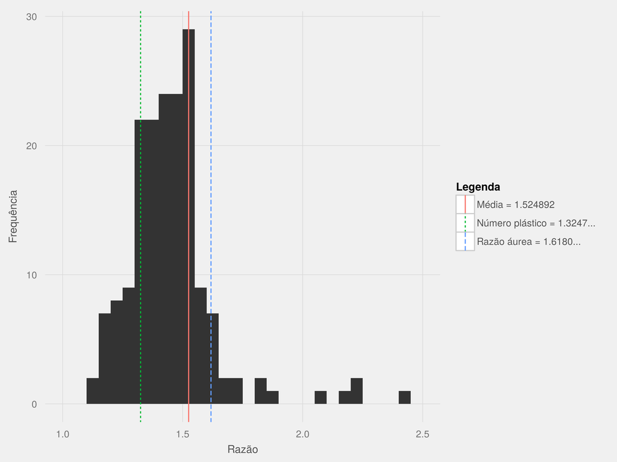

### Francisco de Goya y Lucientes

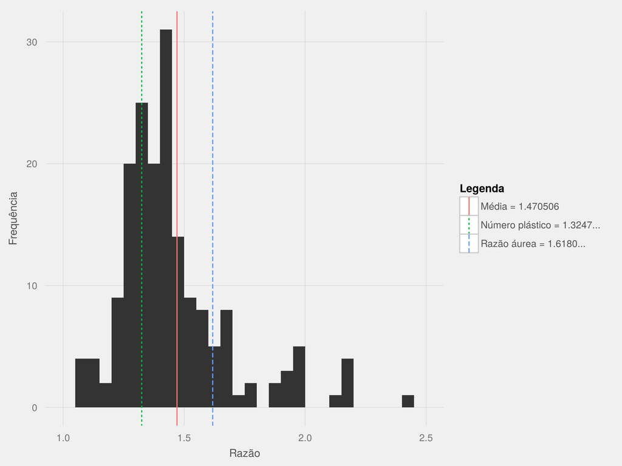

### Paul Gaughin

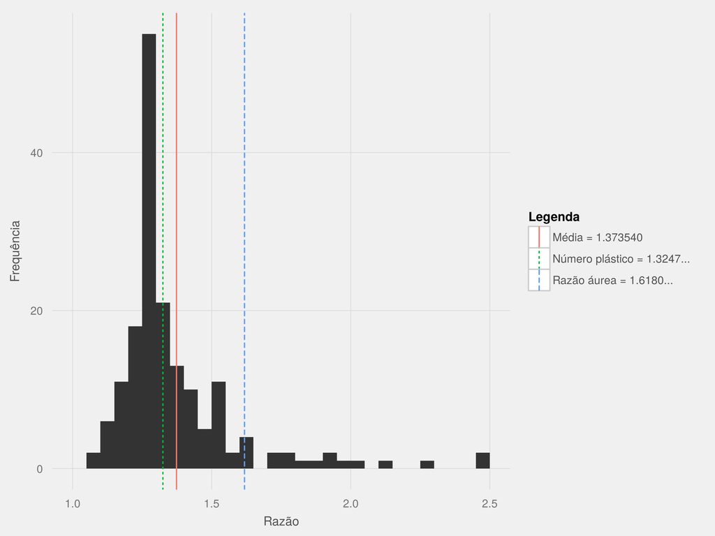

### Edgar Degas

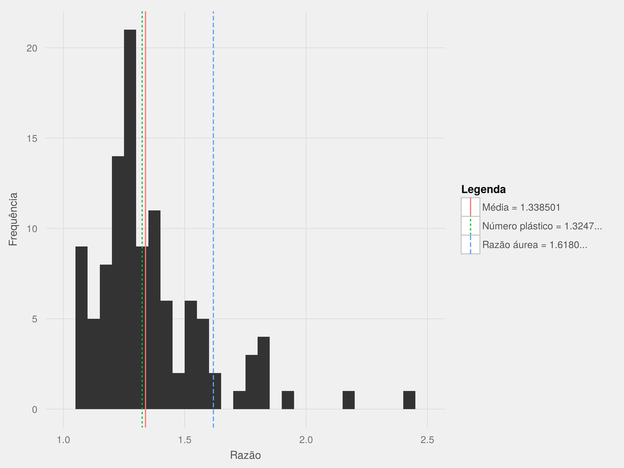

### Sandro Botticelli

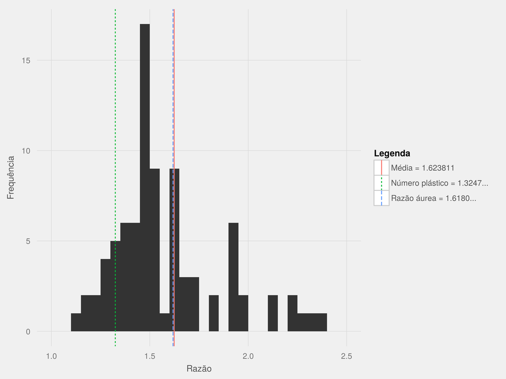

Temos aqui um artista que aparentemente utilizou a razão áurea no dimensionamento de suas obras.

### Caravaggio

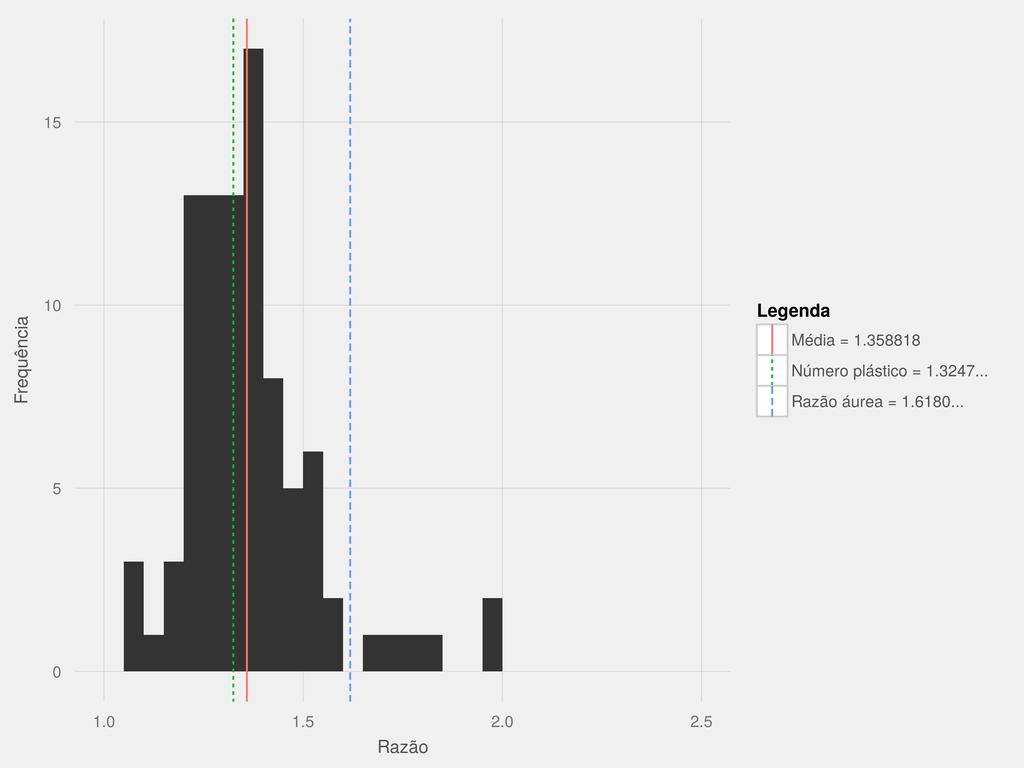